# Logistic regression

## OkCupid Data

We load the packages needed for this analysis and set the number of digits to output to 4.

```r
library(dplyr)
library(ggplot2)
library(stringr)
library(downloader)
library(readr)
options(digits = 4, dplyr.print_max = 1e9)
```

```r
url <- "https://raw.githubusercontent.com/rudeboybert/JSE_OkCupid/master/profiles.csv.zip"
if(!file.exists("profiles.zip"))
  download(url, dest = "profiles.zip", mode = "wb")
if(!file.exists("profiles.csv"))
  unzip("profiles.zip")
set.seed(2016)
if(!exists("profiles")){
  profiles <- read_csv("profiles.csv") %>% sample_frac(size = 0.1)
  saveRDS(profiles, file = "profiles.rds")
} else {
  profiles <- readRDS("profiles.rds")
}
essays <- profiles %>% select(starts_with("essay"))
```

1. In the “Environment” panel of RStudio, click on `profiles`. A spreadsheet of the data should pop up. (Remember this is the same as typing `View(profiles)` in the R console.) Which variables are numerical? Which ones are categorical?

*Here is a listing of the type of each variable in `profiles`:*

| Variable | Type |
| --- | --- |
| `age` | numerical |
| `body_type` | categorical |
| `diet` | categorical |
| `drinks` | categorical |
| `drugs` | categorical |
| `education` | categorical |
| `essay0` - `essay9` | categorical |
| `ethnicity` | categorical |
| `height` | numerical |
| `income` | numerical |
| `job` | categorical |
| `last_online` | categorical |
| `location` | categorical |
| `offspring` | categorical |
| `orientation` | categorical |
| `pets` | categorical |
| `religion` | categorical |
| `sex` | categorical |
| `sign` | categorical |
| `smokes` | categorical |
| `speaks` | categorical |
| `status` | categorical |

2. Pick any one categorical and one numerical variable. Perform an exploratory data analysis of these variables by plotting these variables individually and pairwise. (Note that your results may be messing, i.e., lots of levels. This is the nature of raw data.)

*I chose `age` for my numerical variable and `smokes` for my categorical variable.*

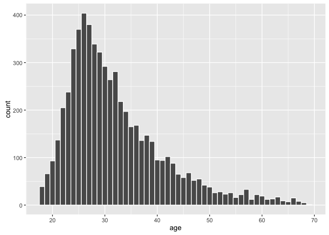

```r
qplot(x = age, data = profiles, geom = "histogram", binwidth = 1, col = I("white"))
```

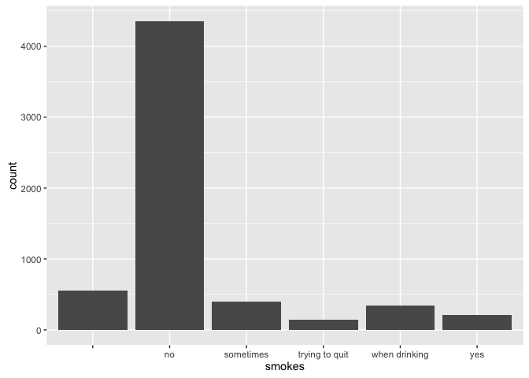

```r
qplot(x = smokes, data = profiles, geom = "bar")
```

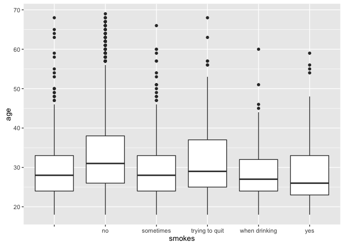

```r
qplot(y = age, x = smokes, data = profiles, geom = "boxplot")
```

3. What proportion of users are female? What are some possible explanations for this result? (Note that the `prop.table` and `table()` functions will likely come in handy here.)

```r
prop.table(table(profiles$sex))
```

```
##
##     f     m
## 0.408 0.592
```

*There are only about 41% of females in this data set. Men may be more willing to be on an online dating site than women. There are surely many other reasonable explanations here.*

4. The essay questions are quite large and do not fit into one screen. Type `print.data.frame(slice(essays, 6))` in R to view the contents of the sixth user, for example. What type of music or TV shows does this user like?

```r
print.data.frame(slice(essays, 6))
```

```
##   essay0 essay1
## 1
##                                                                                                    essay2
## 1 making people laugh...math...dancing (this one could be considered\ndebatable depending on who you ask)
##                 essay3
## 1 my smile and my eyes
##                                                                                                                                                                                                                                                                                                          …
## 1 lots of indie rock...the national...bloc party...the xx...silversun\npickups...also enjoy the random dance concert...<br />\n<br />\ntivo improves my life so much...breaking bad...mad men...sons of\nanarchy...curb...arrested development...the wire<br />\n<br />\ni spend a lot of time reading bu…
##                                                                                                                           essay5
## 1 live music...good television...activities involving bodies of\nwater...my bike...sports (both playing and watching)...ellipsis
##                                                   essay6
## 1 if there are any good shows at the independent tonight
##                                                        essay7 essay8
## 1 out with friends doing typical friday night festivities....
##   essay9
## 1
```

*This user likes Indie Rock and shows like Breaking Bad and Mad Men.*

5. Say you want to display a mosaic plot of categorical variables `x` and `y`, use `mosaicplot(table(x, y))`. Recall that to access variables in a data frame you need to use the `$` as in `dataframe$variable`. Create a mosaic plot of the relationship between `sex` and `orientation`. What can you say about the dating pool for San Francisco OkCupid users? What is the single largest dating demographic group in San Francisco?

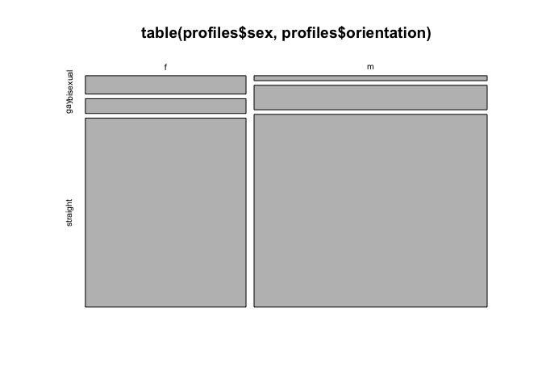

```r
mosaicplot(table(profiles$sex, profiles$orientation))
```

*Based on the mosaic plot, straight males appears to be the largest demographic group in San Francisco.*

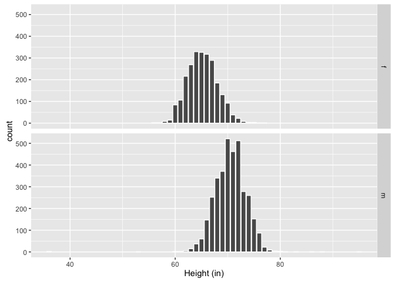

```r
qplot(x = height, data = profiles, geom = "bar",
      color = I("white"), xlab = "Height (in)") +
  facet_grid(sex ~ .)
```

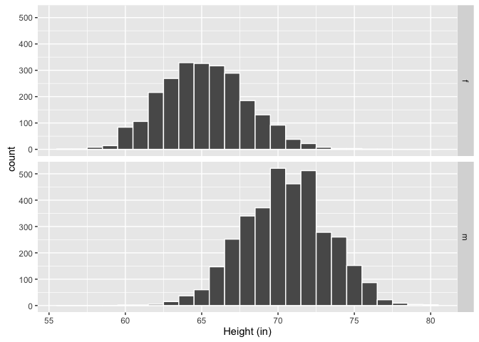

```r
profiles.subset <- profiles %>% filter(height >= 55 & height <= 80)
qplot(x = height, data = profiles.subset, geom = "histogram",
    color = I("white"), binwidth = 1, xlab = "Height (in)") +
  facet_grid(sex ~ .)
```

6. What changed in the plots of `height` for the `profiles` data frame versus the `profiles.subset` data frame? Why?

*Removing the outliers zooms the plot in for both males and females. With the outliers included, `qplot` automatically determines that these values should be plotted.*

7. What phenomenon do you think explains the unusual spike for males at 72 inches? Similarly, what phenomenon do you think explains the anomalous spike for females at 64 inches?

*72 inches corresponds to six feet for men. This is frequently thought of as “normal” height, just as 5’4" corresponds to normal for females.*

8. If I told you someone was 6’4’‘, what would you predict their gender to be?  
   Similarly, what if I told you someone was 5’1’’?

*6’4" would likely be male and 5’1" would likely be female.*

9. For about which height do we start seeing a higher proportion of males than females? You can think of this as a “point of indifference” i.e. we have a similar proportion of males and females being of that height.

*There are more males than females in the sample so we must be careful in directly comparing the counts on the y axis. The difference isn’t enormous though so we will use the bin heights as a proxy here. At around 67 inches we start to see the same number of males than females.*

10. Make a similarly split histogram of age by sex. What do you observe?

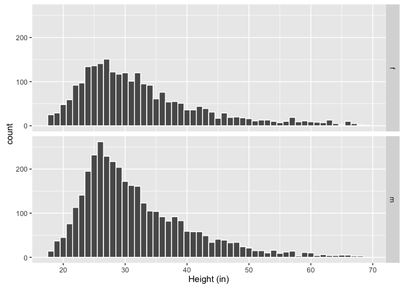

```r
qplot(x = age, data = profiles.subset, geom = "histogram",
    color = I("white"), binwidth = 1, xlab = "Height (in)") +
  facet_grid(sex ~ .)
```

*Both men and women have similar distributions in terms of shape–both right skewed. The larger number of men is likely due to an influx of men between 20 and 30 years of age.*

```r
essays <- profiles.subset %>% select(starts_with("essay")) %>%
  apply(MARGIN = 1, FUN = paste, collapse = " ") %>%
  str_replace_all("\n", " ") %>%
  str_replace_all("<br />", " ")
```

We can use `str_detect` for all users at once as well. For example, we search for the use of the word “wine” and assign it to a new variable in `profiles` called `has.wine`:

```r
profiles.subset <- profiles.subset %>% mutate(has.wine = str_detect(essays, "wine"))
table(profiles.subset$has.wine)
```

```
##
## FALSE  TRUE
##  5053   934
```

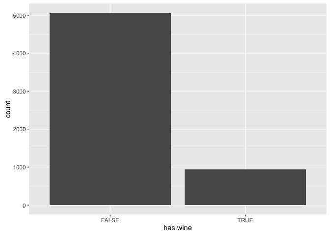

```r
qplot(x = has.wine, data = profiles.subset, geom = "bar")
```

We now display the relationship between the two categorical variables `profiles$has.wine` and `profiles$sex` using mosaic plots.

```r
table(profiles.subset$sex, profiles.subset$has.wine)
```

```
##
##     FALSE TRUE
##   f  1946  500
##   m  3107  434
```

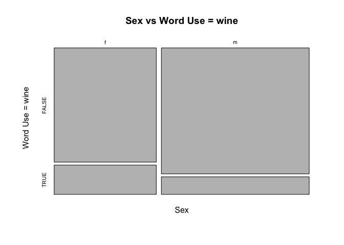

```r
mosaicplot(table(profiles.subset$sex, profiles.subset$has.wine),
  xlab = "Sex", ylab = "Word Use = wine",
  main = "Sex vs Word Use = wine")
```

11. What is your interpretation of the mosaic plot?

```r
profiles.subset <- profiles.subset %>%
  mutate(is.female = ifelse(sex == "f", 1, 0))
sex_height <- glm(is.female ~ height, family = binomial, data = profiles.subset)
summary(sex_height)
```

```
##
## Call:
## glm(formula = is.female ~ height, family = binomial, data = profiles.subset)
##
## Deviance Residuals:
##    Min      1Q  Median      3Q     Max
## -3.080  -0.559  -0.218   0.474   3.560
##
## Coefficients:
##             Estimate Std. Error z value Pr(>|z|)
## (Intercept)  43.7990     1.1093    39.5   <2e-16 ***
## height       -0.6511     0.0164   -39.7   <2e-16 ***
## ---
## Signif. codes:  0 '***' 0.001 '**' 0.01 '*' 0.05 '.' 0.1 ' ' 1
##
## (Dispersion parameter for binomial family taken to be 1)
##
##     Null deviance: 8098.3  on 5986  degrees of freedom
## Residual deviance: 4504.5  on 5985  degrees of freedom
## AIC: 4509
##
## Number of Fisher Scoring iterations: 5
```

```r
inverse.logit <- function(x, m){
  linear.equation <- coef(m)[1] + coef(m)[2] * x
  pred <- 1 / (1 + exp(-linear.equation))
  return(unname(pred))
}
```

12. The first user in the data set’s height is 64 inches. Using the `inverse.logit` function above (make sure to copy it over into a chunk in your report before you try to use it!), what is the fitted probability $\widehat{p}$ that this user is female?

```r
inverse.logit(x = 64, m = sex_height)
```

```
## [1] 0.8938
```

*The predicted probability that a user is female if their height is 64 inches is 0.8938.*

13. What is the fitted probability that a user is female if their height is 75 inches?

```r
inverse.logit(x = 75, m = sex_height)
```

```
## [1] 0.006484
```

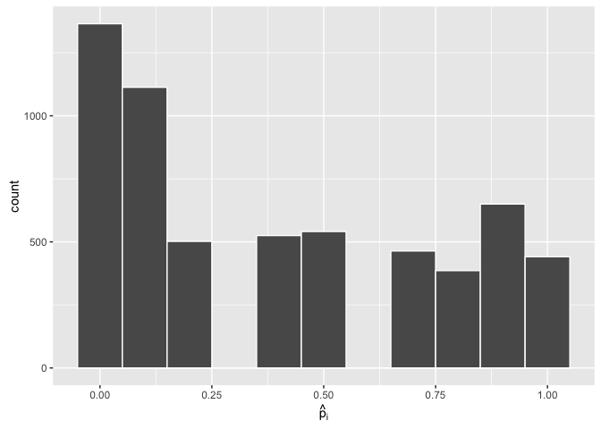

```r
profiles.subset$p.hat <- fitted(sex_height)
qplot(profiles.subset$p.hat, xlab = expression(hat(p)[i]),
  color = I("white"), geom = "histogram", binwidth = 0.1)
```

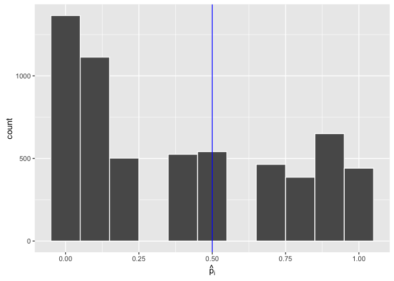

```r
threshold <- 0.5
qplot(profiles.subset$p.hat, xlab = expression(hat(p)[i]),
  color = I("white"), binwidth = 0.1) +
  geom_vline(xintercept = threshold, col = "blue")
```

```r
profiles.subset <- profiles.subset %>%
  mutate(predicted.female = (profiles.subset$p.hat >= threshold))
table(truth = profiles.subset$is.female, prediction = profiles.subset$predicted.female)
```

```
##      prediction
## truth FALSE TRUE
##     0  3021  520
##     1   484 1962
```

14. Of the people we predicted to be female, what proportion did we predict correctly? Of the people who were truly females, what proportion did we predict correctly? Overall, what proportion of users’ sex did we predict correctly?

*Focusing on the `TRUE` column, we see that of the 520 + 1962 = 2482 users we predicted to be female, 1962 of them actually were. This corresponds to a proportion of 0.7905. Similarly, focusing on the `FALSE` column, 3021 of the 3505 were correctly predicted as males corresponding to a proportion of 0.8619. Thus, out of the total number of people in the data set (5987), 4983 were predicted correctly corresponding to a prediction success rate of 0.8323.*

## On Your Own (For practice only - No need to turn in)

- We used 50% as a prediction threshold on the $p_i$’s to predict a user as female. What height does this correspond to? Compare this height to our “point of indifference” height from earlier.

*Using our modified logistic regression equation and this value of $\hat{p} = 0.5$, we can solve the equation for `height` (in inches):*

\begin{align*} ln \left(\dfrac{\hat{p}}{1 - \hat{p}} \right) &= b_0 + b_1 * height \\ ln(0.5/0.5) &= 43.799 - 0.651 * height \\ 0 &= 43.799 - 0.651 * height \\ \Rightarrow height &= 67.28 \end{align*}

*This height matches up to the nearest inch with our “point of indifference” from earlier.*

- Use 25% as a different prediction threshold on the $p_i$’s to declare a user as female. Overall, what proportion of users’ sex did we predict correctly? Compare this value to the earlier one. Which prediction threshold do you prefer?

```r
threshold <- 0.25
profiles.subset <- profiles.subset %>%
  mutate(predicted.female.25 = (profiles.subset$p.hat >= threshold))
table(truth = profiles.subset$is.female, prediction = profiles.subset$predicted.female.25)
```

```
##      prediction
## truth FALSE TRUE
##     0  2681  860
##     1   299 2147
```

*Out of the total number of people in the data set (5987), 4828 were predicted correctly corresponding to a prediction success rate of 0.8064 with a `threshold` of 0.25. This performs slightly worse than the 50% threshold so we should prefer 50%.*

- Fit a logistic regression using both `height` and `has.wine` as predictor variables. What is the fitted probability of being female for a user who is 69 inches tall and does not have the word “wine” in their profile?

```r
multi_log <- glm(is.female ~ height + has.wine, family = binomial, data = profiles.subset)
summary(multi_log)
```

```
##
## Call:
## glm(formula = is.female ~ height + has.wine, family = binomial,
##     data = profiles.subset)
##
## Deviance Residuals:
##    Min      1Q  Median      3Q     Max
## -3.049  -0.531  -0.206   0.497   3.593
##
## Coefficients:
##              Estimate Std. Error z value Pr(>|z|)
## (Intercept)   43.7806     1.1154   39.25  < 2e-16 ***
## height        -0.6524     0.0165  -39.54  < 2e-16 ***
## has.wineTRUE   0.6718     0.1033    6.51  7.7e-11 ***
## ---
## Signif. codes:  0 '***' 0.001 '**' 0.01 '*' 0.05 '.' 0.1 ' ' 1
##
## (Dispersion parameter for binomial family taken to be 1)
##
##     Null deviance: 8098.3  on 5986  degrees of freedom
## Residual deviance: 4461.8  on 5984  degrees of freedom
## AIC: 4468
##
## Number of Fisher Scoring iterations: 5
```

*Since not having wine in their profile corresponds to the baseline level, our predicted equation is:*
$$logit(\hat{p}) = 43.7806 - 0.6526 * height + 0.6718 (0) = 43.7806 - 0.6526 * height$$

*We can, therefore, use the `inverse_logit` function from earlier:*

```r
inverse.logit(x = 69, m = multi_log)
```

```
## [1] 0.2255
```

- Use 50% as a prediction threshold on the $p_i$’s to declare a user as female on our new model based on `height` and `has.wine`. Overall, what proportion of users’ sex did we predict correctly? Did our prediction performance improve? What do these results say about including `has.wine` as a predictor variable?

```r
threshold <- 0.5
profiles.subset$p.hat2 <- fitted(multi_log)
profiles.subset <- profiles.subset %>%
  mutate(predicted.female.new = (profiles.subset$p.hat2 >= threshold))
table(truth = profiles.subset$is.female, prediction = profiles.subset$predicted.female.new)
```

```
##      prediction
## truth FALSE TRUE
##     0  2991  550
##     1   446 2000
```

*Out of the total number of people in the data set (5987), 4991 were predicted correctly corresponding to a prediction success rate of 0.8336 with a `threshold` of 0.50. This value is just barely larger than the success rate we achieved with using `height` alone. This implies that if `height` is included in the model, the addition of `has.wine` does not significantly increase our success rate. Looking at the `summary` of `multi_log`, we do see that `has.wine` has a coeffienct that is statistically different than 0 though.*

## Acknowledgements

We thank OkCupid president and co-founder Christian Rudder for agreeing to our use of this dataset (under the condition that the dataset remains public) and Everett Wetchler for providing the data; the original dataset can be found at https://github.com/rudeboybert/JSE_OkCupid.

This is a product of OpenIntro that is released under a [Creative Commons Attribution-ShareAlike 3.0 Unported](http://creativecommons.org/licenses/by-sa/3.0). This lab was written by Albert Y. Kim, Andrew Bray, and Chester Ismay.